# FDS Final Project: Report #1

# Part 1. Importing Data and Cleaning

## Import an Scraping

Summary of Cleaned Data

|  | location | price | object_type | rooms | living_space | floor | usable_surface | availability | is_hidden |
| --- | --- | --- | --- | --- | --- | --- | --- | --- | --- |
|  | Length :612 | Min. : 30 | Length :612 | Min. : 1.000 | Min. : 1.0 | Min. :-1.000 | Min. : 5.0 | Length :612 | Length :612 |
|  | N.unique :467 | 1st Qu.: 2180 | N.unique : 14 | 1st Qu.: 3.500 | 1st Qu.: 70.0 | 1st Qu.: 2.000 | 1st Qu.: 92.5 | N.unique : 21 | N.unique : 2 |
|  | N.blank : 0 | Median : 3500 | N.blank : 0 | Median : 5.000 | Median :111.0 | Median : 3.000 | Median :125.0 | N.blank : 0 | N.blank : 0 |
|  | Min.nchar: 15 | Mean : 4039 | Min.nchar: 4 | Mean : 4.866 | Mean :127.1 | Mean : 3.646 | Mean :133.7 | Min.nchar: 2 | Min.nchar: 9 |
|  | Max.nchar: 51 | 3rd Qu.: 5250 | Max.nchar: 18 | 3rd Qu.: 6.000 | 3rd Qu.:170.0 | 3rd Qu.: 5.000 | 3rd Qu.:178.2 | Max.nchar: 11 | Max.nchar: 10 |
|  | NA | Max. :22800 | NA | Max. :13.000 | Max. :530.0 | Max. :50.000 | Max. :250.0 | NA | NA |
|  | NA | NAs :15 | NA | NAs :24 | NAs :93 | NAs :214 | NAs :582 | NA | NA |

**Data Cleaning and Preparation** *The cleaned data-set ends up with 612 rows and 9 variables , and saved as rental_data_final_epfl_612.csv for further analysis.*

**Explanation parse_number():** *I used it to clean numeric strings that contain suffixes or symbols. To prevent extreme distortions caused by outliers in price_m2 often produced by incorrectly recorded very small surface values, we filter out infinite values, NAs, and keep only logically coherent ranges of living area.* **parse_number()** *It’s use to find the first numbers inside of a chain of text, ignoring characters or other symbols, spaces or commas*

# Exploratory Data Analysis

## Part 2. Price vs. Living Space

[figure not shown]

## Part 3. Number of properties by postcode

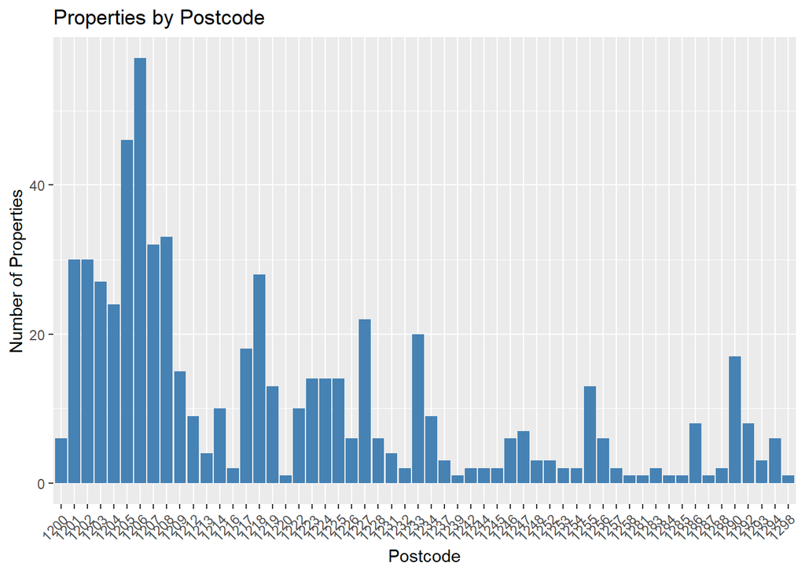

**Comments:** *The plot shows that the agency is more active in other areas where there is more listings, other areas have less listings indicating lower activity*

## Part 4. Price vs. Living Space by Postcode and Floor

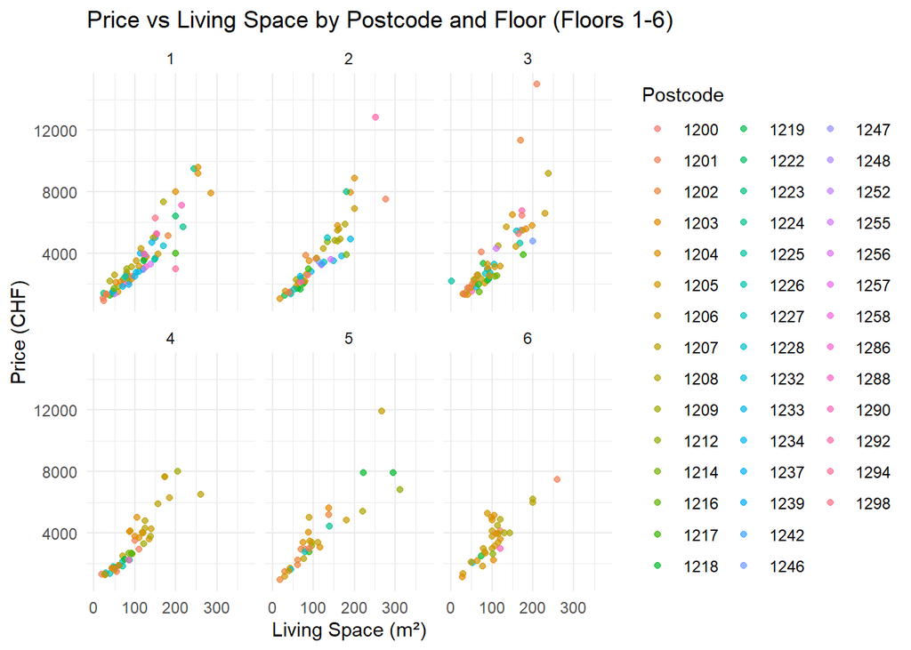

The most expensive combination is postcode 1292 on floor 2 with an average price of 12854 CHF

The least expensive combination is postcode 1219 on floor 2 with an average of 1245 CHF